# Movie Awards

## 5.3 Check Correlations Again

There are still some moderate correlations, in particular between the engineered Popularity.log and lifetime_gross.log. lifetime_gross.log will be dropped.

```r
corr_simple(drop=c("nrOfWins","nrOfWins.sqr"))
```

```
##               Var1                Var2       Freq
## 810 Popularity.log  lifetime_gross.log  0.6168315
## 813  ratingInteger nrOfNominations.sqr  0.4215055
## 735          Drama        duration.log  0.3661610
## 839 Popularity.log nrOfNominations.sqr  0.3648694
## 120      Adventure           Animation  0.3443654
## 616         Comedy            Thriller -0.3125063
## 262  ratingInteger               Drama  0.3100243
```

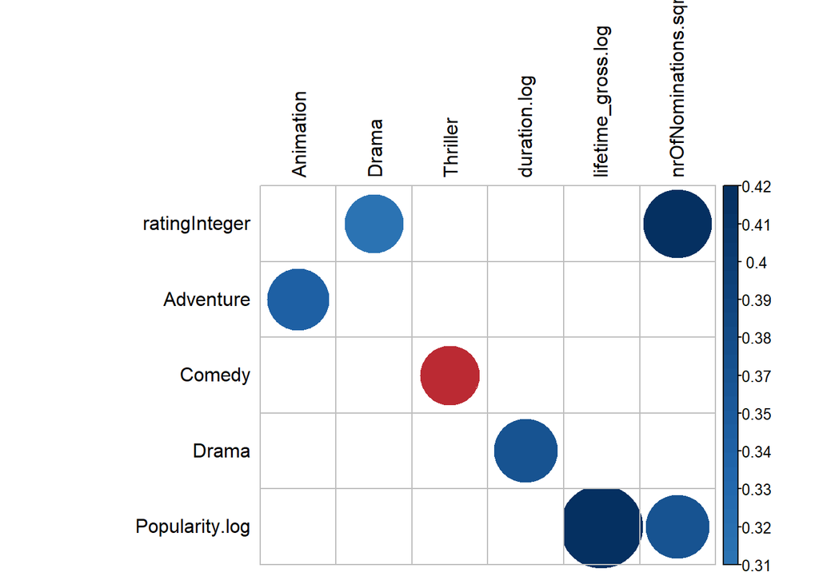

```r
movies <- movies %>% select(-lifetime_gross.log)
```

## 5.4 Normalize Data

Normalize the data frame so that model is not skewed by different types of measurements.

```r
#normalize dataframe
normalize <- function(x)(x - mean(x, na.rm=T))/sd(x, na.rm=T)

movies <- movies %>% mutate_at(vars(year.log,duration.log,Popularity.log,nrOfNominations.sqr), normalize)

movies %>% glimpse()
```

```
## Observations: 3,234
## Variables: 30
## $ ratingInteger       <fct> 8, 8, 8, 8, 8, 8, 8, 8, 8, 8, 8, 8, 8, 8, ...
## $ nrOfWins            <int> 20, 18, 10, 20, 13, 22, 26, 21, 10, 26, 0,...
## $ nrOfGenre           <fct> 3, 3, 3, 3, 2, 1, 2, 2, 2, 3, 3, 2, 2, 3, ...
## $ Action              <lgl> FALSE, FALSE, FALSE, FALSE, FALSE, FALSE, ...
## $ Adventure           <lgl> FALSE, TRUE, FALSE, FALSE, FALSE, FALSE, F...
## $ Animation           <lgl> FALSE, FALSE, FALSE, FALSE, FALSE, FALSE, ...
## $ Biography           <lgl> FALSE, TRUE, FALSE, FALSE, FALSE, FALSE, F...
## $ Comedy              <lgl> TRUE, FALSE, TRUE, FALSE, FALSE, FALSE, TR...
## $ Crime               <lgl> FALSE, TRUE, TRUE, FALSE, TRUE, FALSE, FAL...
## $ Documentary         <lgl> FALSE, FALSE, FALSE, FALSE, FALSE, FALSE, ...
## $ Drama               <lgl> TRUE, FALSE, TRUE, TRUE, TRUE, TRUE, FALSE...
## $ Family              <lgl> FALSE, FALSE, FALSE, FALSE, FALSE, FALSE, ...
## $ Fantasy             <lgl> FALSE, FALSE, FALSE, FALSE, FALSE, FALSE, ...
```

[output cut: 17 more lines]

## 5.5 Training and Testing Sets

Using 70% data to train the model and 30% to test

```r
#for use with linear regression
#convert to numeric dummy variables
movies_num <- dummy_cols(movies) %>% select(-ratingInteger,-nrOfGenre)
movies_num <- movies_num %>% mutate_if(is.logical,as.integer)

set.seed(123)
train_num <- movies_num %>% sample_frac(0.7)
test_num <- movies_num %>% setdiff(train_num)

#for use with regression trees
set.seed(123)
train <- movies %>% sample_frac(0.7)
test <- movies %>% setdiff(train)
```

# 6 Models

## 6.1 Linear Regression (by AIC)

R-squared: 76.16%

```r
#Linear Regression Model
lmodel <- lm(nrOfWins.sqr ~ . -nrOfWins, data = train_num)

#best model by AIC
lmodel_AIC <- lmodel %>% step() #automatically steps through and removes features based on getting the lowest AIC value for the model
```

```r
lmodel_AIC %>% summary()
```

```
##
## Call:
## lm(formula = nrOfWins.sqr ~ Action + Adventure + Animation +
##     Comedy + Crime + Documentary + Family + Fantasy + Musical +
##     Sport + Thriller + year.log + nrOfNominations.sqr + ratingInteger_8 +
##     ratingInteger_9 + ratingInteger_7 + ratingInteger_3, data = train_num)
##
## Residuals:
##     Min      1Q  Median      3Q     Max
## -2.6783 -0.2975 -0.0806  0.2379  5.2776
##
## Coefficients:
##                     Estimate Std. Error t value Pr(>|t|)
## (Intercept)          1.30080    0.03954  32.900  < 2e-16 ***
## Action              -0.09596    0.04243  -2.262 0.023800 *
## Adventure           -0.16690    0.04962  -3.364 0.000782 ***
## Animation           -0.24769    0.08371  -2.959 0.003119 **
## Comedy              -0.05812    0.03571  -1.628 0.103743
## Crime               -0.06572    0.04167  -1.577 0.114915
## Documentary          0.29848    0.10263   2.908 0.003671 **
## Family              -0.17882    0.06086  -2.938 0.003335 **
## Fantasy             -0.16028    0.06083  -2.635 0.008477 **
## Musical             -0.32488    0.12400  -2.620 0.008849 **
## Sport               -0.15691    0.08348  -1.879 0.060307 .
## Thriller            -0.16025    0.04687  -3.419 0.000641 ***
## year.log            -0.06703    0.01646  -4.072 4.83e-05 ***
## nrOfNominations.sqr  1.17918    0.01832  64.367  < 2e-16 ***
## ratingInteger_8      0.72878    0.05804  12.557  < 2e-16 ***
## ratingInteger_9      1.13361    0.37559   3.018 0.002571 **
## ratingInteger_7      0.09801    0.03670   2.671 0.007626 **
## ratingInteger_3      0.53320    0.26342   2.024 0.043075 *
## ---
## Signif. codes:  0 '***' 0.001 '**' 0.01 '*' 0.05 '.' 0.1 ' ' 1
##
## Residual standard error: 0.7395 on 2246 degrees of freedom
## Multiple R-squared:  0.7616, Adjusted R-squared:  0.7598
## F-statistic: 422.1 on 17 and 2246 DF,  p-value: < 2.2e-16
```

```r
#nrOfWins.sqr ~ Adventure + Biography + Crime + Documentary + Drama + Family + Music + Romance + SciFi + War + Western + year.log + duration.log + Popularity.log + lifetime_gross.log + nrOfNominations.sqr + ratingInteger_8 + ratingInteger_9 + ratingInteger_3 + nrOfGenre_2 + nrOfGenre_1

#variable importance sorted from highest to lowest
varImp_sort <- function(mod){
  imp <- as.data.frame(varImp(mod))
  imp <- data.frame(names   = rownames(imp),
                  overall = imp$Overall)
  imp[order(imp$overall,decreasing = T),]
}

varImp_sort(lmodel_AIC)
```

```
##                  names   overall
## 13 nrOfNominations.sqr 64.367270
## 14     ratingInteger_8 12.556771
## 12            year.log  4.071592
## 11            Thriller  3.418661
## 2            Adventure  3.363628
## 15     ratingInteger_9  3.018198
## 3            Animation  2.959006
## 7               Family  2.938143
## 6          Documentary  2.908228
## 16     ratingInteger_7  2.670608
## 8              Fantasy  2.634791
## 9              Musical  2.620138
## 1               Action  2.261886
## 17     ratingInteger_3  2.024129
## 10               Sport  1.879488
## 4               Comedy  1.627632
## 5                Crime  1.577093
```

```r
model_performance(lmodel_AIC, metrics=c("AIC","R2","RMSE"))
```

```
##        AIC        R2 R2_adjusted     RMSE
## 1 5078.372 0.7616017   0.7597972 0.736547
```

## 6.2 Linear Regression (by p-value)

R-squared: 76.08%

```r
#best model by p-value
lmodel_p <- lm(nrOfWins.sqr ~ Action + Adventure + Animation + Documentary + Family + Fantasy + Musical + Thriller + year.log + nrOfNominations.sqr + ratingInteger_8 + ratingInteger_9 + ratingInteger_7 + ratingInteger_3, data=train_num)

summary(lmodel_p)
```

```
##
## Call:
## lm(formula = nrOfWins.sqr ~ Action + Adventure + Animation +
##     Documentary + Family + Fantasy + Musical + Thriller + year.log +
##     nrOfNominations.sqr + ratingInteger_8 + ratingInteger_9 +
##     ratingInteger_7 + ratingInteger_3, data = train_num)
##
## Residuals:
##     Min      1Q  Median      3Q     Max
## -2.6465 -0.2846 -0.0875  0.2446  5.2499
##
## Coefficients:
##                     Estimate Std. Error t value Pr(>|t|)
## (Intercept)          1.24363    0.03007  41.355  < 2e-16 ***
## Action              -0.09489    0.04077  -2.328  0.02002 *
## Adventure           -0.14146    0.04863  -2.909  0.00366 **
## Animation           -0.24827    0.08371  -2.966  0.00305 **
## Documentary          0.32374    0.10165   3.185  0.00147 **
## Family              -0.17522    0.06080  -2.882  0.00399 **
## Fantasy             -0.14238    0.06046  -2.355  0.01861 *
## Musical             -0.30486    0.12381  -2.462  0.01388 *
## Thriller            -0.12759    0.04371  -2.919  0.00355 **
## year.log            -0.06741    0.01647  -4.093  4.4e-05 ***
## nrOfNominations.sqr  1.18655    0.01812  65.472  < 2e-16 ***
## ratingInteger_8      0.73589    0.05730  12.842  < 2e-16 ***
## ratingInteger_9      1.15512    0.37548   3.076  0.00212 **
## ratingInteger_7      0.09993    0.03624   2.758  0.00587 **
## ratingInteger_3      0.51859    0.26350   1.968  0.04918 *
## ---
## Signif. codes:  0 '***' 0.001 '**' 0.01 '*' 0.05 '.' 0.1 ' ' 1
##
## Residual standard error: 0.7402 on 2249 degrees of freedom
## Multiple R-squared:  0.7608, Adjusted R-squared:  0.7593
## F-statistic: 510.9 on 14 and 2249 DF,  p-value: < 2.2e-16
```

```r
varImp_sort(lmodel_p)
```

```
##                  names   overall
## 10 nrOfNominations.sqr 65.472472
## 11     ratingInteger_8 12.841734
## 9             year.log  4.093424
## 4          Documentary  3.184796
## 12     ratingInteger_9  3.076355
## 3            Animation  2.965857
## 8             Thriller  2.918901
## 2            Adventure  2.908852
## 5               Family  2.881881
## 13     ratingInteger_7  2.757768
## 7              Musical  2.462326
## 6              Fantasy  2.354938
## 1               Action  2.327691
## 14     ratingInteger_3  1.968060
```

```r
model_performance(lmodel_p, metrics=c("AIC","R2","RMSE"))
```

```
##        AIC       R2 R2_adjusted      RMSE
## 1 5079.953 0.760802    0.759313 0.7377813
```

## 6.3 Linear Regression (by important)

```r
#best model by important features
lmodel_i <- lm(nrOfWins.sqr ~ Action + Biography + War + Adventure + Animation + Documentary + Family + Fantasy + Musical + Thriller + year.log + nrOfNominations.sqr + ratingInteger_8 + ratingInteger_9 + Popularity.log, data=train_num)

summary(lmodel_i)
```

```
##
## Call:
## lm(formula = nrOfWins.sqr ~ Action + Biography + War + Adventure +
##     Animation + Documentary + Family + Fantasy + Musical + Thriller +
##     year.log + nrOfNominations.sqr + ratingInteger_8 + ratingInteger_9 +
##     Popularity.log, data = train_num)
##
## Residuals:
##     Min      1Q  Median      3Q     Max
## -2.7362 -0.2886 -0.0887  0.2452  5.2733
##
## Coefficients:
##                     Estimate Std. Error t value Pr(>|t|)
## (Intercept)          1.28665    0.02418  53.206  < 2e-16 ***
## Action              -0.10255    0.04149  -2.472 0.013518 *
## Biography            0.11062    0.06860   1.613 0.106968
## War                  0.15325    0.10614   1.444 0.148924
## Adventure           -0.14242    0.04880  -2.919 0.003549 **
## Animation           -0.22866    0.08379  -2.729 0.006403 **
## Documentary          0.35859    0.10397   3.449 0.000573 ***
## Family              -0.18839    0.06066  -3.105 0.001923 **
## Fantasy             -0.13555    0.06081  -2.229 0.025914 *
## Musical             -0.28054    0.12486  -2.247 0.024742 *
## Thriller            -0.12513    0.04448  -2.813 0.004948 **
## year.log            -0.07228    0.01689  -4.279 1.96e-05 ***
## nrOfNominations.sqr  1.19355    0.01833  65.123  < 2e-16 ***
## ratingInteger_8      0.65351    0.05220  12.519  < 2e-16 ***
## ratingInteger_9      1.09466    0.37544   2.916 0.003585 **
## Popularity.log       0.01135    0.01862   0.609 0.542377
## ---
## Signif. codes:  0 '***' 0.001 '**' 0.01 '*' 0.05 '.' 0.1 ' ' 1
##
## Residual standard error: 0.7414 on 2248 degrees of freedom
## Multiple R-squared:  0.7601, Adjusted R-squared:  0.7585
## F-statistic: 474.9 on 15 and 2248 DF,  p-value: < 2.2e-16
```

```r
varImp_sort(lmodel_i)
```

```
##                  names    overall
## 12 nrOfNominations.sqr 65.1232511
## 13     ratingInteger_8 12.5190632
## 11            year.log  4.2785257
## 6          Documentary  3.4491320
## 7               Family  3.1054819
## 4            Adventure  2.9187415
## 14     ratingInteger_9  2.9156455
## 10            Thriller  2.8131797
## 5            Animation  2.7289316
## 1               Action  2.4717679
## 9              Musical  2.2469220
## 8              Fantasy  2.2289763
## 2            Biography  1.6126184
## 3                  War  1.4438378
## 15      Popularity.log  0.6093147
```

```r
model_performance(lmodel_p, metrics=c("AIC","R2","RMSE"))
```

```
##        AIC       R2 R2_adjusted      RMSE
## 1 5079.953 0.760802    0.759313 0.7377813
```

## 6.4 Regression Tree

R-squared: 80.17 %

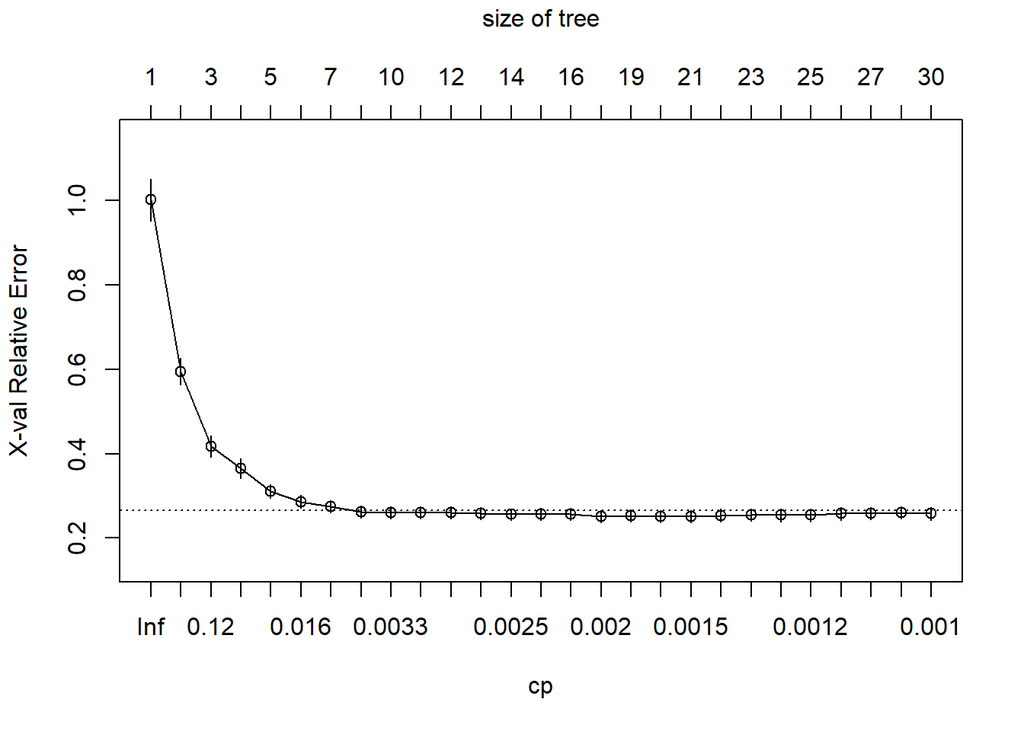

```r
#building a decision tree
dtModel <- rpart(nrOfWins.sqr~.-nrOfWins, data = train, method="anova", cp=.001)

#view results
plotcp(dtModel) #visualize cross validation results
```

```r
varImp_sort(dtModel) #view variable importance
```

```
##                  names    overall
## 13 nrOfNominations.sqr 2.72303897
## 15       ratingInteger 1.64837122
## 18            year.log 1.57368578
## 9         duration.log 1.54856353
## 2            Adventure 1.06531127
## 8                Drama 0.98672139
## 14      Popularity.log 0.90774993
## 3            Animation 0.71807295
## 16             Romance 0.37244225
## 12           nrOfGenre 0.31369780
## 1               Action 0.29138194
## 7          Documentary 0.25872023
## 17            Thriller 0.18495035
## 4            Biography 0.15721218
## 5               Comedy 0.12583402
## 6                Crime 0.04990904
## 10             Fantasy 0.03593187
## 11             Musical 0.01555749
## 19              Family 0.00000000
## 20              Horror 0.00000000
## 21               Music 0.00000000
## 22             Mystery 0.00000000
## 23                News 0.00000000
## 24               SciFi 0.00000000
## 25               Short 0.00000000
## 26               Sport 0.00000000
## 27                 War 0.00000000
## 28             Western 0.00000000
```

```r
printcp(dtModel) #display results
```

```
##
## Regression tree:
## rpart(formula = nrOfWins.sqr ~ . - nrOfWins, data = train, method = "anova",
##     cp = 0.001)
##
## Variables actually used in tree construction:
##  [1] Action              Adventure           Documentary
##  [4] Drama               duration.log        nrOfGenre
##  [7] nrOfNominations.sqr Popularity.log      ratingInteger
## [10] year.log
##
## Root node error: 5152/2264 = 2.2756
##
## n= 2264
##
```

[output cut: 28 more lines]

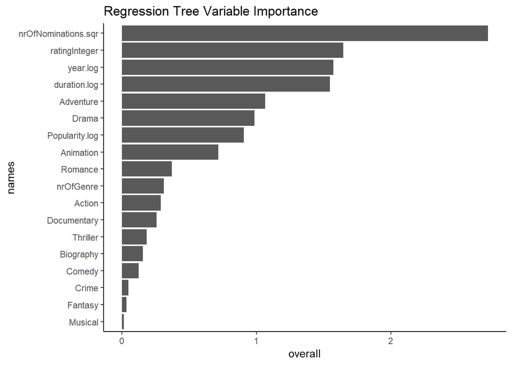

```r
#plot variable importance
impvar <- varImp_sort(dtModel) %>% filter(overall>0) %>% arrange(overall) %>% mutate(names = factor(names, unique(names)))
impvar %>% ggplot(aes(names, overall))+
  geom_bar(stat = "identity")+
  coord_flip()+
  labs(title="Regression Tree Variable Importance")
```

```r
#gather R-squared value
tmp <- printcp(dtModel)
```

```
##
## Regression tree:
## rpart(formula = nrOfWins.sqr ~ . - nrOfWins, data = train, method = "anova",
##     cp = 0.001)
##
## Variables actually used in tree construction:
##  [1] Action              Adventure           Documentary
##  [4] Drama               duration.log        nrOfGenre
##  [7] nrOfNominations.sqr Popularity.log      ratingInteger
## [10] year.log
##
## Root node error: 5152/2264 = 2.2756
##
## n= 2264
##
```

[output cut: 28 more lines]

```r
rsq.val <- 1-tmp[nrow(tmp),3]   #extract R-squared from final split
cat("\nR-squared: ", round(rsq.val*100,2),"% \n")
```

```
##
## R-squared:  80.17 %
```

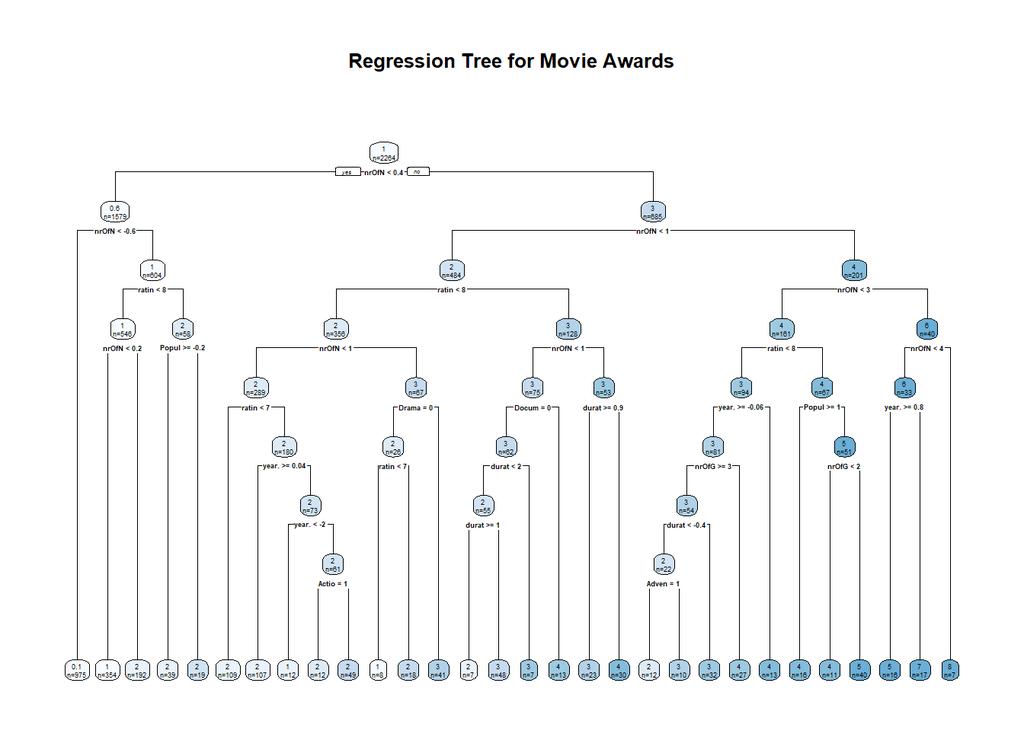

```r
#plot tree
rpart.plot(dtModel, extra=1, varlen=-1, digits=1, main="Regression Tree for Movie Awards")
```

## 6.5 Random Forest

R-squared: 76.76%

```r
set.seed(123)
rfModel <- randomForest(nrOfWins.sqr ~ .-nrOfWins, ntree=400, mtry=15, data=train, importance=TRUE, corr.bias=TRUE)
rfModel
```

```
##
## Call:
##  randomForest(formula = nrOfWins.sqr ~ . - nrOfWins, data = train,      ntree = 400, mtry = 15, importance = TRUE, corr.bias = TRUE)
##                Type of random forest: regression
##                      Number of trees: 400
## No. of variables tried at each split: 15
##
##           Mean of squared residuals: 0.5288754
##                     % Var explained: 76.76
##   Bias correction applied:
##   Intercept:  -0.0122175
##       Slope:  1.003082
```

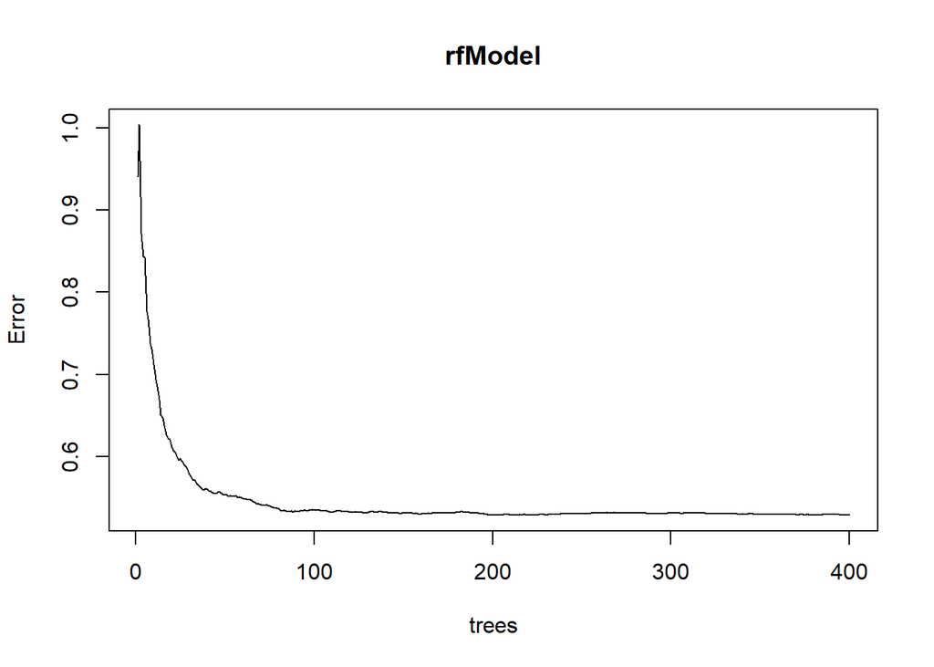

```r
plot(rfModel)
```

```r
varImp_sort(rfModel)
```

```
##                  names      overall
## 28 nrOfNominations.sqr 129.24593114
## 1        ratingInteger  35.29635020
## 27      Popularity.log  16.65149160
## 25            year.log  15.66764158
## 9          Documentary  11.80645162
## 26        duration.log  11.42987778
## 10               Drama   9.65046160
## 3               Action   8.99498244
## 4            Adventure   7.75123052
## 7               Comedy   6.66576224
## 13              Horror   6.34186205
## 24             Western   5.02248371
## 11              Family   4.46829261
## 8                Crime   4.15115262
## 18             Romance   3.54580046
## 2            nrOfGenre   2.54821846
## 22            Thriller   2.22670331
## 23                 War   2.11520398
## 12             Fantasy   1.90159669
## 19               SciFi   1.80570831
## 5            Animation   1.18555968
## 15             Musical   1.10543935
## 21               Sport   0.43425805
## 16             Mystery   0.04092723
## 17                News   0.00000000
## 20               Short   0.00000000
## 14               Music  -0.01011599
## 6            Biography  -0.73679521
```

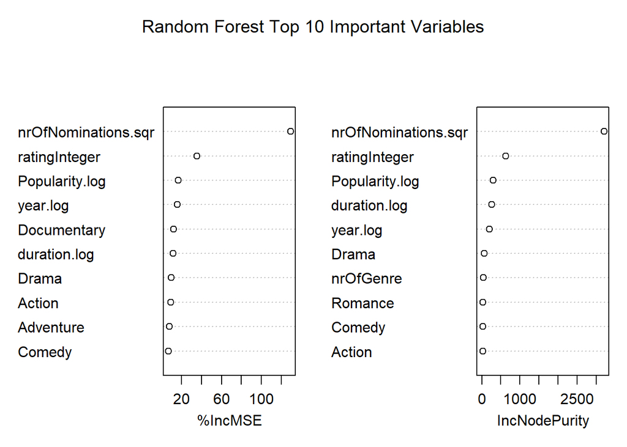

```r
varImpPlot(rfModel, n.var=10, main="Random Forest Top 10 Important Variables")
```

# 7 Model Performance

Performance is being measured by R-squared. This value is derived from using the square of the correlation between the actual values and predicted values.

The following R-squared values were calculated using the test set: * lmodel_AIC - 69.27% * lmodel_p - 69.57% * lmodel_i - 69.77% * dtModel - 61.48% * rfModel - 64.85%

```
## lmodel_AIC R-squared:  69.27 %
```

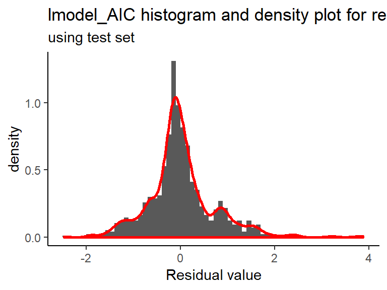

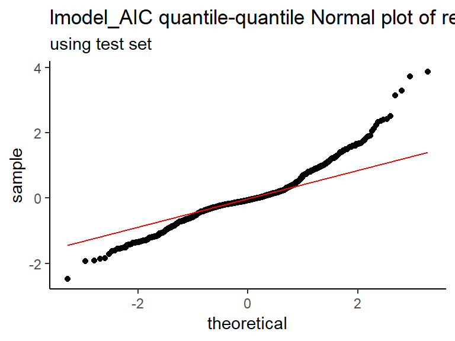

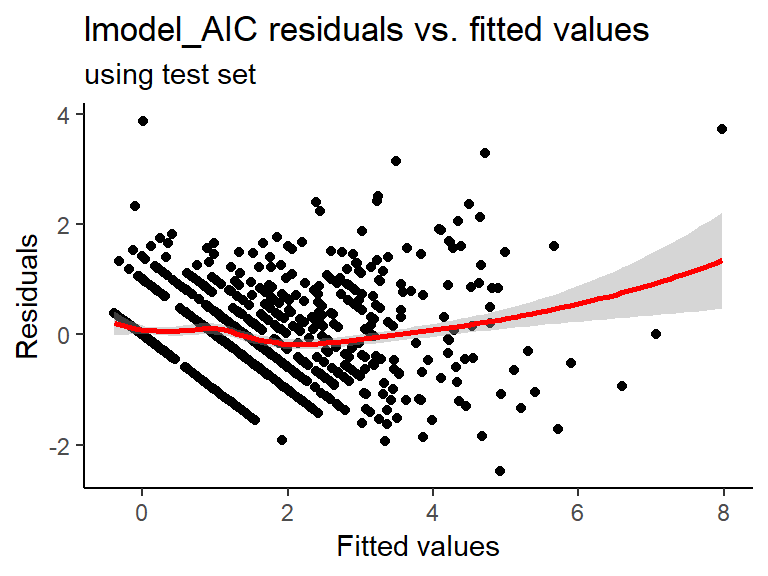

```r
#prediction and accuracy function
predict_score <- function(mod, data){
  mod_name <- deparse(substitute(mod))

  #predict results
  data <- data %>% mutate(score = predict(mod, newdata=data), #predict results using the model
                         resids = nrOfWins.sqr - score,
                         predictedwins = round(score*score)) #unsquare the results and round to whole number- there cannot be partial awards

  #return accuracy
  df_cor <- data %>% select(predictedwins,nrOfWins)
  corr <- cor(df_cor)^2
  corr[lower.tri(corr,diag=TRUE)] <- NA  #Prepare to drop duplicates and correlations of 1
  corr <- as.data.frame(as.table(corr)) #Turn into a 3-column table
  corr <- na.omit(corr) #remove the NA values from above
  cat(mod_name, "R-squared: ", round(corr$Freq*100, 2),"% \n") #print accuracy

  #plot results
  h <- hist(data$resids, breaks = "FD", plot = FALSE) #histogram with Freedman-Diaconis rule for binwidth
  hd <- data %>% ggplot(aes(resids, ..density..))+
    geom_histogram(breaks=h$breaks)+
    geom_density(color="red", size=1)+
    labs(title=str_c(mod_name, " histogram and density plot for residuals"), x="Residual value", subtitle="using test set")
  qq <- data %>% ggplot(aes(sample=resids))+
    geom_qq()+
    geom_qq_line(color="red")+
    labs(title=str_c(mod_name, " quantile-quantile Normal plot of residuals"), subtitle="using test set")
  fit <- data %>% ggplot(aes(score, resids))+
    geom_point()+
    geom_smooth(method="loess", color="red")+
    labs(title=str_c(mod_name, " residuals vs. fitted values"), x="Fitted values", y="Residuals", subtitle="using test set")
  hd %>% print()
  qq %>% print()
  fit %>% print()
}

#predict with the test data
AIC_pred <- predict_score(lmodel_AIC, test_num)
```

```r
p_pred <- predict_score(lmodel_p, test_num)
```

```
## lmodel_p R-squared:  69.57 %
```

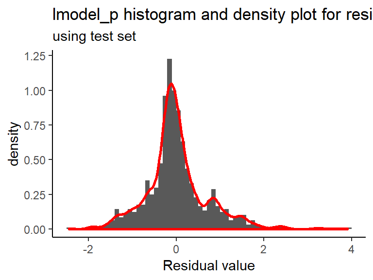

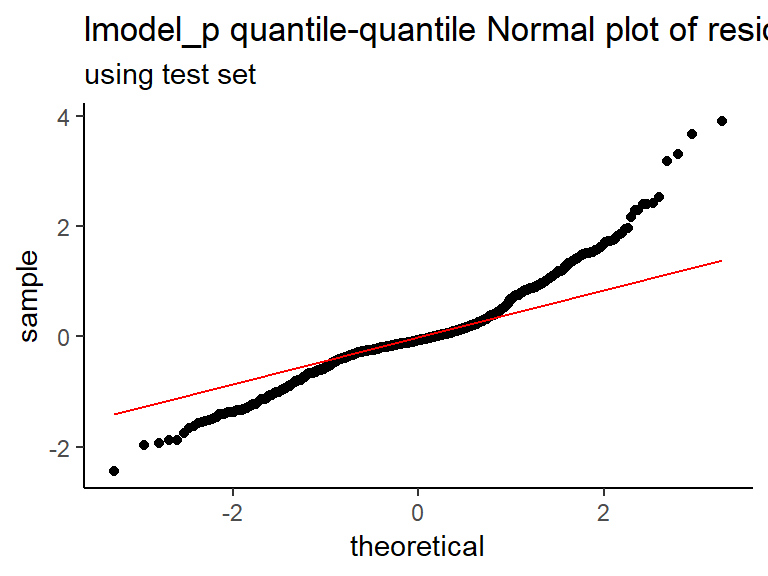

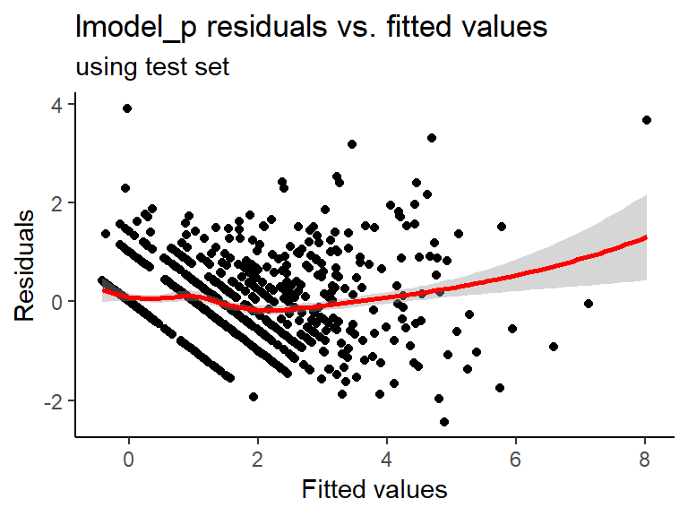

```r
i_pred <- predict_score(lmodel_i, test_num)
```

```
## lmodel_i R-squared:  69.77 %
```

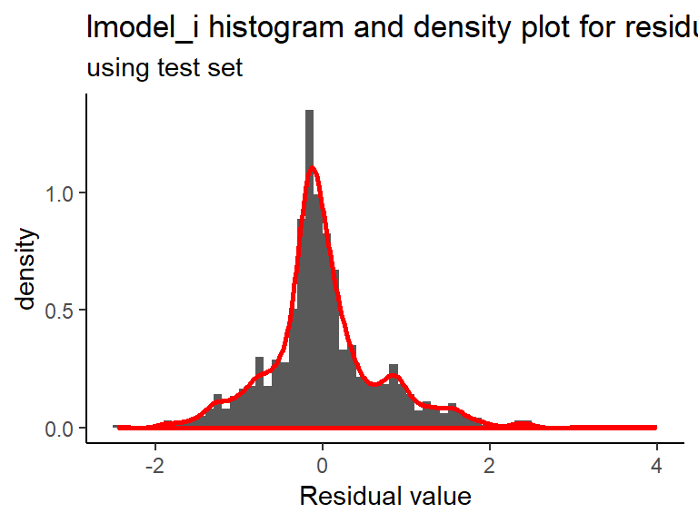

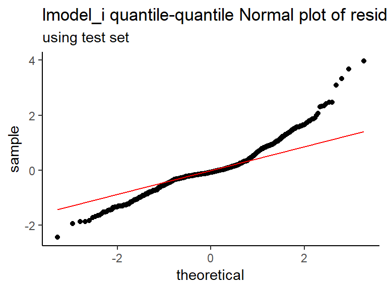

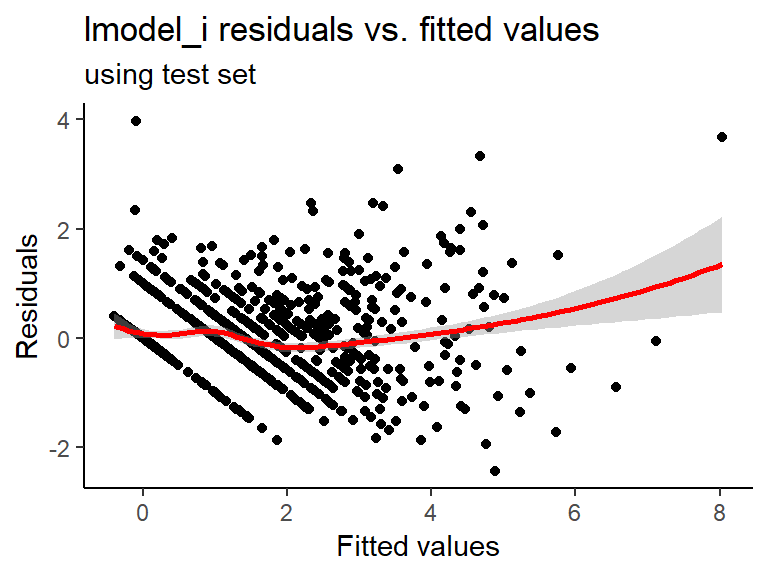

```r
dt_pred <- predict_score(dtModel, test)
```

```
## dtModel R-squared:  61.48 %
```

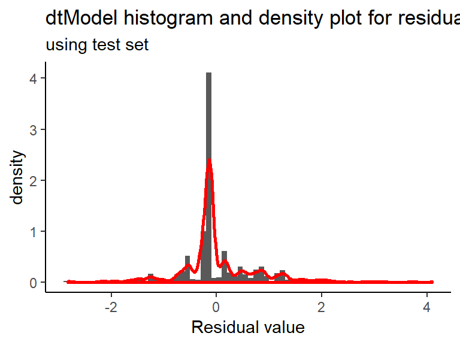

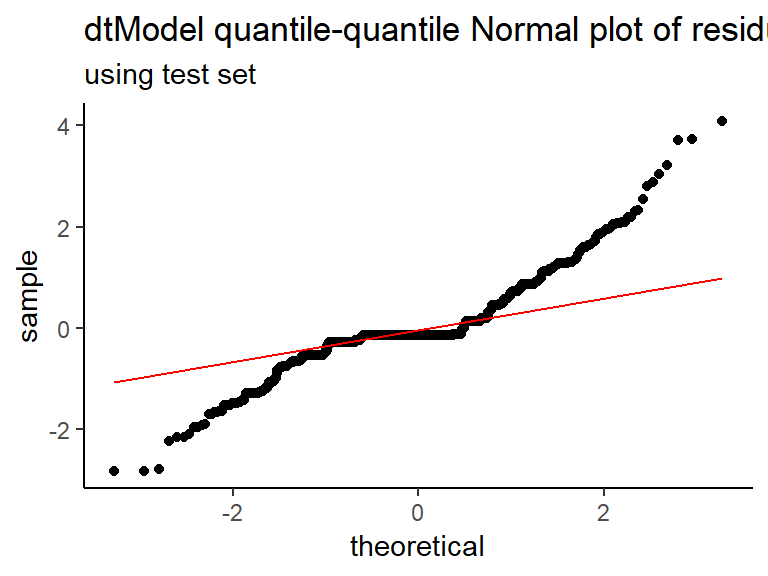

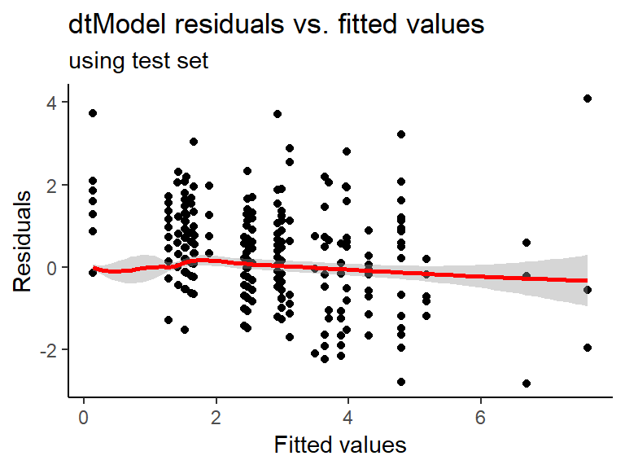

```r
rf_pred <- predict_score(rfModel, test)
```

```
## rfModel R-squared:  64.85 %
```

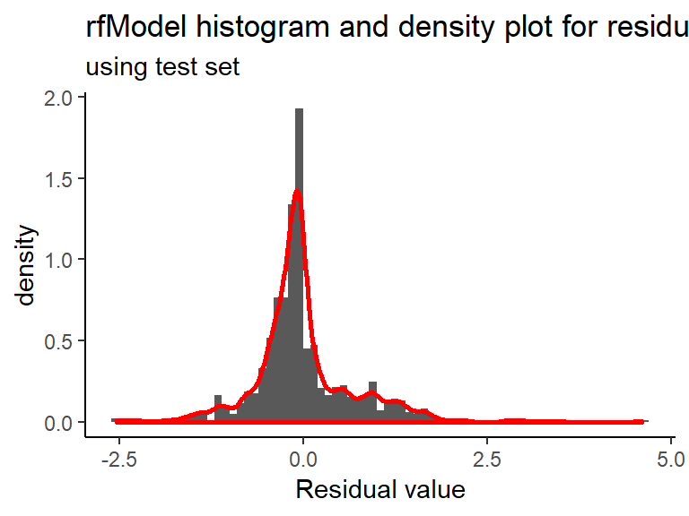

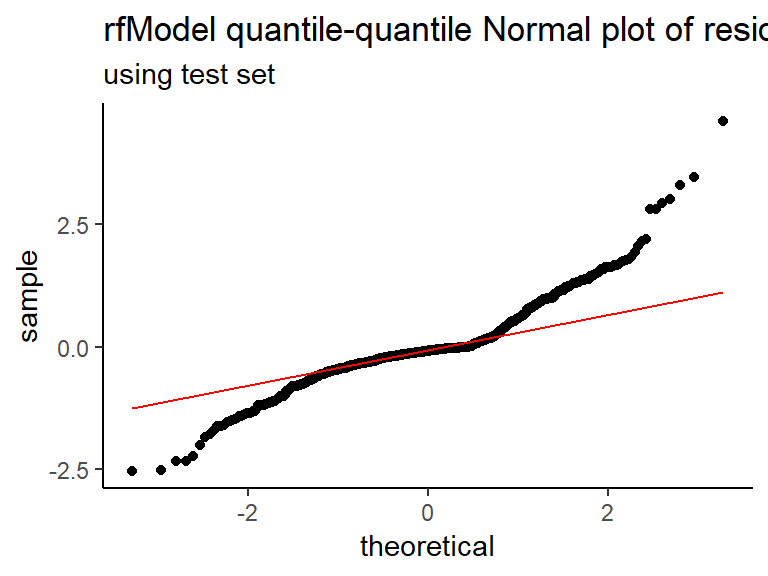

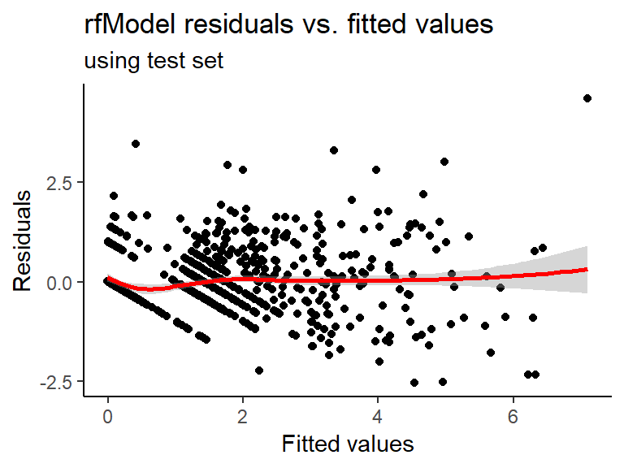

# 8 Conclusion

lmodel_i is the best model with an R-squared of 69.77% against the test data. It shows that nrOfWins.sqr is modeled by nrOfNominations.sqr, ratingInteger_8, year.log, Documentary, Family, Adventure, ratingInteger_9, Thriller, Animation, Action, Musical, Fantasy, Biography, War, and Popularity.log. The residuals compared to fitted values are in a fairly straight line and close to 0 except at the higher end. The residuals plot is a fairly normal distribution. The quantile quantile plot is reasonably straight, except at the ends where there is more noise.

To improve accuracy results, nrOfWins could have been turned into a binary variable for whether an award was earned or not. Doing a really quick generalized linear model of this (not shown since it is out of scope of this project) resulted in ~95% accuracy against the test set. This project is predicting number of awards, however, and not whether an award was received or not.

Another thing that could have been done to improve the models would be to gather more movie data including actors/actresses, producer, etc. These basic movie stats are likely not enough to explain all the variance with number of movie awards.